# Using gamar

Marc Choisy

2016-01-28

[figure not shown]

This vignette shows how to install and use the `gamar` package.

## Installing `gamar`

The package is currently on the GitHub repository. To install it from this repository you can use the `install_github` function from the `devtools` package. If this package is not installed on your system, install it

```r
> install.packages("devtools")
```

Then you can install the `gamar` package by typing:

```r
> devtools::install_github("choisy/gamar")
```

Note that the `gamar` package depends on the `XML` package. The installation of `gamar` package automatically installs the `XML` too, if not already installed on your system. Then, you can load and attach the `gamar` library:

```r
> library(gamar)
```

Note that you need the GAMA platform (version > 1.6.2) to be installed on your machine. For now, you have to set the path to the GAMA folder yourself:

```r
> defpath("absolute_path_to_your_GAMA_folder")
```

## An simple SIR epidemic model

There are a number of example files in the `examples` directory of the library:

```r
> (f <- system.file("examples",package="gamar"))
[1] "/Library/Frameworks/R.framework/Versions/3.2/Resources/library/gamar/examples"
> dir(f)
[1] "sir.gaml" "sir.xml"
```

Move the GAML and XML files of the SIR model and experiment to the working directory:

```r
> dir()
character(0)
> file.copy(paste0(f,"/sir.xml"),".")
[1] TRUE
> file.copy(paste0(f,"/sir.gaml"),".")
[1] TRUE
> dir()
[1] "sir.gaml" "sir.xml"
```

Now, you can run the experiment:

```r
> system.time(simulation <- run("sir.xml"))
   user  system elapsed
 25.902   0.744  10.527
```

And explore and plot the results:

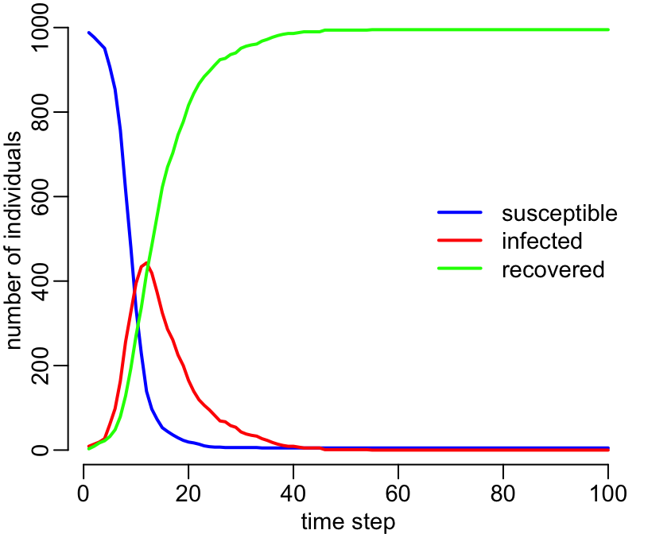

```r
> str(simulation)
'data.frame':   100 obs. of  4 variables:
 $ Step       : num  1 2 3 4 5 6 7 8 9 10 ...
 $ Susceptible: num  988 977 964 951 907 854 758 616 481 334 ...
 $ Infectious : num  9 14 19 27 61 98 163 256 326 395 ...
 $ Recovered  : num  3 9 17 22 32 48 79 128 193 271 ...
> head(simulation)
  Step Susceptible Infectious Recovered
1    1         988          9         3
2    2         977         14         9
3    3         964         19        17
4    4         951         27        22
5    5         907         61        32
6    6         854         98        48
> with(simulation, {
+   plot(Susceptible,col="blue",type="l",lwd=2,
+        xlab="time step",ylab="number of individuals")
+   lines(Infectious,col="red",lwd=2)
+   lines(Recovered,col="green",lwd=2)
+ })
> legend("right",c("susceptible","infected","recovered"),
+        col=c("blue","red","green"),lwd=2,lty=1,bty="n")
```